# Práctico 1 -Clase 4 de Mayo

Marcelo Cena

Mayo de 2018

### Diagnosticando Cancer:

- Investigaremos ahora la utilidad del ML para detectar cancer aplicando el algoritmo kNN a mediciones de biopsias de mujeres, utilizando el conjunto de datos “Breast Cancer Winscosin Diagnostic” del UCI ML Repository http://archive.ics.uci.edu/ml que incluye 569 ejemplos de biopsias, en cada una se midieron 32 features (diferentes caracteristicas de las nucleos celulares) y el diagnostico codificado como M (Maligno) o B (Benigno).

```r
data <- read.csv("http://archive.ics.uci.edu/ml/machine-learning-databases/breast-cancer-wisconsin/wdbc.data",header=FALSE)
data <- data[-1]
str(data)
```

```
## 'data.frame':    569 obs. of  31 variables:
##  $ V2 : Factor w/ 2 levels "B","M": 2 2 2 2 2 2 2 2 2 2 ...
##  $ V3 : num  18 20.6 19.7 11.4 20.3 ...
##  $ V4 : num  10.4 17.8 21.2 20.4 14.3 ...
##  $ V5 : num  122.8 132.9 130 77.6 135.1 ...
##  $ V6 : num  1001 1326 1203 386 1297 ...
##  $ V7 : num  0.1184 0.0847 0.1096 0.1425 0.1003 ...
##  $ V8 : num  0.2776 0.0786 0.1599 0.2839 0.1328 ...
##  $ V9 : num  0.3001 0.0869 0.1974 0.2414 0.198 ...
##  $ V10: num  0.1471 0.0702 0.1279 0.1052 0.1043 ...
##  $ V11: num  0.242 0.181 0.207 0.26 0.181 ...
##  $ V12: num  0.0787 0.0567 0.06 0.0974 0.0588 ...
##  $ V13: num  1.095 0.543 0.746 0.496 0.757 ...
##  $ V14: num  0.905 0.734 0.787 1.156 0.781 ...
##  $ V15: num  8.59 3.4 4.58 3.44 5.44 ...
```

[output cut: 17 more lines]

```r
normalize <- function(x) {
  return ((x-min(x))/(max(x)-min(x)))
}
data_n <- as.data.frame(lapply(data[2:31], normalize))
summary(data_n$V3)
```

```
##    Min. 1st Qu.  Median    Mean 3rd Qu.    Max.
##  0.0000  0.2233  0.3024  0.3382  0.4164  1.0000
```

```r
summary(data_n$V8)
```

```
##    Min. 1st Qu.  Median    Mean 3rd Qu.    Max.
##  0.0000  0.1397  0.2247  0.2606  0.3405  1.0000
```

### Entrenando un clasificador:

Notese que dichos conjuntos de datos deben ser representativos del conjunto de datos, i.e. **metodos de muestreo aleatorios**!

```r
data_train <- data_n[1:469, ]
data_test  <- data_n[470:569, ]
```

Excluimos la variable objetivo (Benigno/Maligno), pero necesitamos guardar estos factores en vectores!

```r
data_train_labels <- data[1:469, 1]
data_test_labels  <- data[470:569, 1]
```

### Ejercicios.

Los valores correctos estan en la diagonal de la matriz, 98% de precision para unas pocas lineas de R!

```r
library(class)
data_test_pred <- knn(train=data_train, cl=data_train_labels, test=data_test, k=21)

library(gmodels)
CrossTable(x=data_test_labels, y=data_test_pred, prop.chisq = FALSE)
```

```
##
##
##    Cell Contents
## |-------------------------|
## |                       N |
## |           N / Row Total |
## |           N / Col Total |
## |         N / Table Total |
## |-------------------------|
##
##
## Total Observations in Table:  100
##
##
##                  | data_test_pred
## data_test_labels |         B |         M | Row Total |
## -----------------|-----------|-----------|-----------|
##                B |        77 |         0 |        77 |
##                  |     1.000 |     0.000 |     0.770 |
##                  |     0.975 |     0.000 |           |
##                  |     0.770 |     0.000 |           |
## -----------------|-----------|-----------|-----------|
##                M |         2 |        21 |        23 |
##                  |     0.087 |     0.913 |     0.230 |
##                  |     0.025 |     1.000 |           |
##                  |     0.020 |     0.210 |           |
## -----------------|-----------|-----------|-----------|
##     Column Total |        79 |        21 |       100 |
##                  |     0.790 |     0.210 |           |
## -----------------|-----------|-----------|-----------|
##
##
```

- Mejore el rendimiento utilizando una normalizacion con z-scores provista por la funcion scale() de R.

**Aplicamos normalizacion Z-score**

```r
library(class)
mean_data <- as.data.frame(lapply(data[2:31], mean))
sd_data <- as.data.frame(lapply(data[2:31], sd))

data_n <- as.data.frame(scale(data[2:31], center=mean_data, scale=sd_data))
summary(data_n$V3)
```

```
##    Min. 1st Qu.  Median    Mean 3rd Qu.    Max.
## -2.0279 -0.6888 -0.2149  0.0000  0.4690  3.9678
```

```r
summary(data_n$V8)
```

```
##    Min. 1st Qu.  Median    Mean 3rd Qu.    Max.
## -1.6087 -0.7464 -0.2217  0.0000  0.4934  4.5644
```

```r
library(class)
data_test_pred <- knn(train=data_train, test=data_test, cl=data_train_labels, k=21)
library(gmodels)
CrossTable(x=data_test_labels, y=data_test_pred, prop.chisq = FALSE)
```

```
##
##
##    Cell Contents
## |-------------------------|
## |                       N |
## |           N / Row Total |
## |           N / Col Total |
## |         N / Table Total |
## |-------------------------|
##
##
## Total Observations in Table:  100
##
##
##                  | data_test_pred
## data_test_labels |         B |         M | Row Total |
## -----------------|-----------|-----------|-----------|
##                B |        77 |         0 |        77 |
##                  |     1.000 |     0.000 |     0.770 |
##                  |     0.975 |     0.000 |           |
##                  |     0.770 |     0.000 |           |
## -----------------|-----------|-----------|-----------|
##                M |         2 |        21 |        23 |
##                  |     0.087 |     0.913 |     0.230 |
##                  |     0.025 |     1.000 |           |
##                  |     0.020 |     0.210 |           |
## -----------------|-----------|-----------|-----------|
##     Column Total |        79 |        21 |       100 |
##                  |     0.790 |     0.210 |           |
## -----------------|-----------|-----------|-----------|
##
##
```

- Pruebe algunos valores alternativos de k=1, 5, 11, 15, 21 y seleccione el mejor valor de k.

```r
library(class)
data_test_pred1 <- knn(train=data_train, test=data_test, cl=data_train_labels, k=1)

library(gmodels)
CrossTable(x=data_test_labels, y=data_test_pred1, prop.chisq = FALSE)
```

```
##
##
##    Cell Contents
## |-------------------------|
## |                       N |
## |           N / Row Total |
## |           N / Col Total |
## |         N / Table Total |
## |-------------------------|
##
##
## Total Observations in Table:  100
##
##
##                  | data_test_pred1
## data_test_labels |         B |         M | Row Total |
## -----------------|-----------|-----------|-----------|
##                B |        72 |         5 |        77 |
##                  |     0.935 |     0.065 |     0.770 |
##                  |     0.973 |     0.192 |           |
##                  |     0.720 |     0.050 |           |
## -----------------|-----------|-----------|-----------|
##                M |         2 |        21 |        23 |
##                  |     0.087 |     0.913 |     0.230 |
##                  |     0.027 |     0.808 |           |
##                  |     0.020 |     0.210 |           |
## -----------------|-----------|-----------|-----------|
##     Column Total |        74 |        26 |       100 |
##                  |     0.740 |     0.260 |           |
## -----------------|-----------|-----------|-----------|
##
##
```

```r
library(class)
data_test_pred5 <- knn(train=data_train, test=data_test, cl=data_train_labels, k=5)

library(gmodels)
CrossTable(x=data_test_labels, y=data_test_pred5, prop.chisq = FALSE)
```

```
##
##
##    Cell Contents
## |-------------------------|
## |                       N |
## |           N / Row Total |
## |           N / Col Total |
## |         N / Table Total |
## |-------------------------|
##
##
## Total Observations in Table:  100
##
##
##                  | data_test_pred5
## data_test_labels |         B |         M | Row Total |
## -----------------|-----------|-----------|-----------|
##                B |        74 |         3 |        77 |
##                  |     0.961 |     0.039 |     0.770 |
##                  |     1.000 |     0.115 |           |
##                  |     0.740 |     0.030 |           |
## -----------------|-----------|-----------|-----------|
##                M |         0 |        23 |        23 |
##                  |     0.000 |     1.000 |     0.230 |
##                  |     0.000 |     0.885 |           |
##                  |     0.000 |     0.230 |           |
## -----------------|-----------|-----------|-----------|
##     Column Total |        74 |        26 |       100 |
##                  |     0.740 |     0.260 |           |
## -----------------|-----------|-----------|-----------|
##
##
```

```r
library(class)
data_test_pred11 <- knn(train=data_train, test=data_test, cl=data_train_labels, k=11)
library(gmodels)
CrossTable(x=data_test_labels, y=data_test_pred11, prop.chisq = FALSE)
```

```
##
##
##    Cell Contents
## |-------------------------|
## |                       N |
## |           N / Row Total |
## |           N / Col Total |
## |         N / Table Total |
## |-------------------------|
##
##
## Total Observations in Table:  100
##
##
##                  | data_test_pred11
## data_test_labels |         B |         M | Row Total |
## -----------------|-----------|-----------|-----------|
##                B |        76 |         1 |        77 |
##                  |     0.987 |     0.013 |     0.770 |
##                  |     0.987 |     0.043 |           |
##                  |     0.760 |     0.010 |           |
## -----------------|-----------|-----------|-----------|
##                M |         1 |        22 |        23 |
##                  |     0.043 |     0.957 |     0.230 |
##                  |     0.013 |     0.957 |           |
##                  |     0.010 |     0.220 |           |
## -----------------|-----------|-----------|-----------|
##     Column Total |        77 |        23 |       100 |
##                  |     0.770 |     0.230 |           |
## -----------------|-----------|-----------|-----------|
##
##
```

```r
library(class)
data_test_pred15 <- knn(train=data_train, test=data_test, cl=data_train_labels, k=15)

library(gmodels)
CrossTable(x=data_test_labels, y=data_test_pred15, prop.chisq = FALSE)
```

```
##
##
##    Cell Contents
## |-------------------------|
## |                       N |
## |           N / Row Total |
## |           N / Col Total |
## |         N / Table Total |
## |-------------------------|
##
##
## Total Observations in Table:  100
##
##
##                  | data_test_pred15
## data_test_labels |         B |         M | Row Total |
## -----------------|-----------|-----------|-----------|
##                B |        77 |         0 |        77 |
##                  |     1.000 |     0.000 |     0.770 |
##                  |     0.975 |     0.000 |           |
##                  |     0.770 |     0.000 |           |
## -----------------|-----------|-----------|-----------|
##                M |         2 |        21 |        23 |
##                  |     0.087 |     0.913 |     0.230 |
##                  |     0.025 |     1.000 |           |
##                  |     0.020 |     0.210 |           |
## -----------------|-----------|-----------|-----------|
##     Column Total |        79 |        21 |       100 |
##                  |     0.790 |     0.210 |           |
## -----------------|-----------|-----------|-----------|
##
##
```

```r
library(class)
data_test_pred21 <- knn(train=data_train, test=data_test, cl=data_train_labels, k=21)

library(gmodels)
CrossTable(x=data_test_labels, y=data_test_pred21, prop.chisq = FALSE)
```

```
##
##
##    Cell Contents
## |-------------------------|
## |                       N |
## |           N / Row Total |
## |           N / Col Total |
## |         N / Table Total |
## |-------------------------|
##
##
## Total Observations in Table:  100
##
##
##                  | data_test_pred21
## data_test_labels |         B |         M | Row Total |
## -----------------|-----------|-----------|-----------|
##                B |        77 |         0 |        77 |
##                  |     1.000 |     0.000 |     0.770 |
##                  |     0.975 |     0.000 |           |
##                  |     0.770 |     0.000 |           |
## -----------------|-----------|-----------|-----------|
##                M |         2 |        21 |        23 |
##                  |     0.087 |     0.913 |     0.230 |
##                  |     0.025 |     1.000 |           |
##                  |     0.020 |     0.210 |           |
## -----------------|-----------|-----------|-----------|
##     Column Total |        79 |        21 |       100 |
##                  |     0.790 |     0.210 |           |
## -----------------|-----------|-----------|-----------|
##
##
```

Ahora verificamos cual predice mejor para casos benignos:

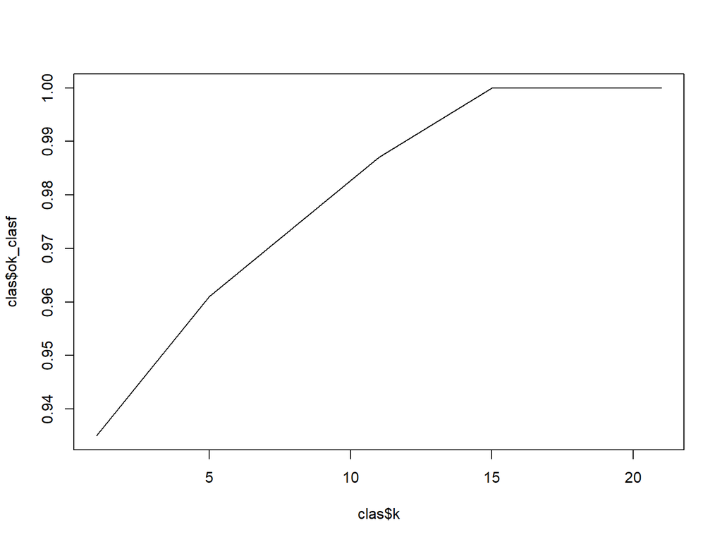

```r
# Cargamos en un dataframe resultados para cada valor de k de:
# clasificaciones realizadas correctamente -> ok_clasf
# clasificaciones realizadas incorrectamente -> miss_clasf

k = c(1,5,11,15,21)
miss_clasf = c(0.065, 0.039, 0.013, 0.00, 0.0)
ok_clasf = c(0.935, 0.961, 0.987, 1.00, 1.00)
clas <- data.frame(k, miss_clasf, ok_clasf)
plot(clas$k, clas$ok_clasf, type='l')
```

Ahora verificamos cual predice mejor para casos malignos:

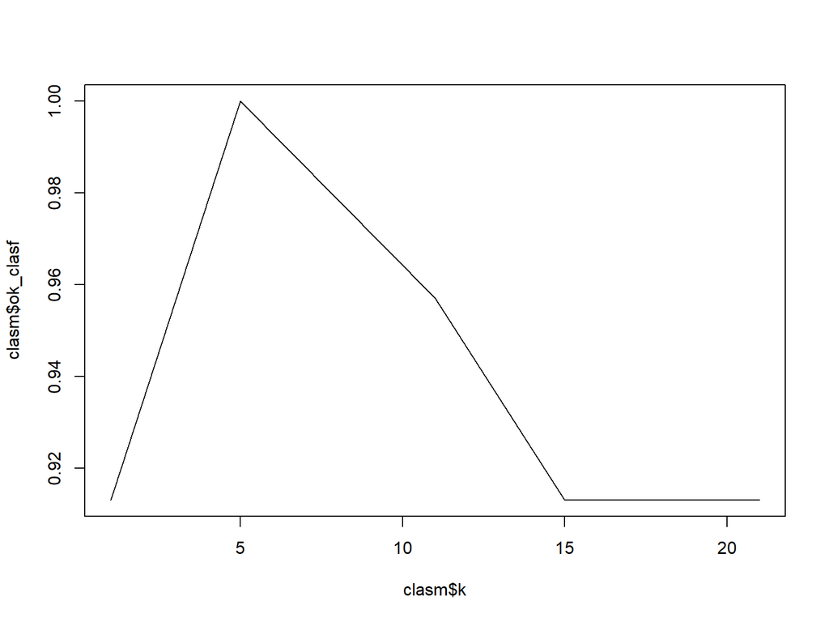

```r
# Cargamos en un dataframe resultados para cada valor de k de:
# clasificaciones realizadas correctamente -> ok_clasf
# clasificaciones realizadas incorrectamente -> miss_clasf

km = c(1,5,11,15,21)
miss_clasfm = c(0.087, 0.00, 0.043, 0.087, 0.087)
ok_clasfm = c(0.913, 1.00, 0.957, 0.913, 0.913)
clasm <- data.frame(km, miss_clasfm, ok_clasfm)
plot(clasm$k, clasm$ok_clasf, type='l')
```

CONCLUSION: Creo que usar K=5 es mas conveninete, ya que, Si bien la muestra cn K=5 fue la mejor para predecir los casos malignos, presentó cierta cantidad de falsos positivos (maligno) cuando en realidad el tumor era benigno. Creo que es mejor no descartar casos malignos que dar falsos positivos.

- mientras termina su merecido cafe verifique si el resultado cambia utilizando paciente elegidos aleatoriamente para el conjunto de validacion.

```r
# seteamos la semilla
set.seed(97)
n <- dim(data_n)[1]
n_training <- floor(n * .82)
training_indicesr <- sample(x=1:n, size=n_training, replace=FALSE)
data_trainr <- data_n[training_indicesr, ]
data_testr  <- data_n[-training_indicesr, ]
data_train_labelsr <- data[training_indicesr, 1]
data_test_labelsr  <- data[-training_indicesr, 1]
dim(data_trainr)
```

```
## [1] 466  30
```

```r
dim(data_testr)
```

```
## [1] 103  30
```

# correremos una vez mas knn para el k elegido (k=5)

```r
data_test_predr <- knn(train=data_trainr, test=data_testr, cl=data_train_labelsr, k=5)
CrossTable(x=data_test_labelsr, y=data_test_predr, prop.chisq = FALSE)
```

```
##
##
##    Cell Contents
## |-------------------------|
## |                       N |
## |           N / Row Total |
## |           N / Col Total |
## |         N / Table Total |
## |-------------------------|
##
##
## Total Observations in Table:  103
##
##
##                   | data_test_predr
## data_test_labelsr |         B |         M | Row Total |
## ------------------|-----------|-----------|-----------|
##                 B |        70 |         0 |        70 |
##                   |     1.000 |     0.000 |     0.680 |
##                   |     0.972 |     0.000 |           |
##                   |     0.680 |     0.000 |           |
## ------------------|-----------|-----------|-----------|
##                 M |         2 |        31 |        33 |
##                   |     0.061 |     0.939 |     0.320 |
##                   |     0.028 |     1.000 |           |
##                   |     0.019 |     0.301 |           |
## ------------------|-----------|-----------|-----------|
##      Column Total |        72 |        31 |       103 |
##                   |     0.699 |     0.301 |           |
## ------------------|-----------|-----------|-----------|
##
##
```

```r
# seteamos la semilla

set.seed(497)
n <- dim(data_n)[1]
n_training <- floor(n * .82)
training_indicesr1 <- sample(x=1:n, size=n_training, replace=FALSE)
data_trainr1 <- data_n[training_indicesr1, ]
data_testr1  <- data_n[-training_indicesr1, ]
data_train_labelsr1 <- data[training_indicesr1, 1]
data_test_labelsr1  <- data[-training_indicesr1, 1]
dim(data_trainr1)
```

```
## [1] 466  30
```

```r
dim(data_testr1)
```

```
## [1] 103  30
```

```r
data_test_predr1 <- knn(train=data_trainr1, test=data_testr1, cl=data_train_labelsr1, k=5)
CrossTable(x=data_test_labelsr1, y=data_test_predr1, prop.chisq = FALSE)
```

```
##
##
##    Cell Contents
## |-------------------------|
## |                       N |
## |           N / Row Total |
## |           N / Col Total |
## |         N / Table Total |
## |-------------------------|
##
##
## Total Observations in Table:  103
##
##
##                    | data_test_predr1
## data_test_labelsr1 |         B |         M | Row Total |
## -------------------|-----------|-----------|-----------|
##                  B |        56 |         2 |        58 |
##                    |     0.966 |     0.034 |     0.563 |
##                    |     0.949 |     0.045 |           |
##                    |     0.544 |     0.019 |           |
## -------------------|-----------|-----------|-----------|
##                  M |         3 |        42 |        45 |
##                    |     0.067 |     0.933 |     0.437 |
##                    |     0.051 |     0.955 |           |
##                    |     0.029 |     0.408 |           |
## -------------------|-----------|-----------|-----------|
##       Column Total |        59 |        44 |       103 |
##                    |     0.573 |     0.427 |           |
## -------------------|-----------|-----------|-----------|
##
##
```

Peor ahora tambien clasifica mal los casos benignos, evidentemente, la eleccion de la semilla influye grandemente en el resultado